# Compare patient OsteoCar references

Stephanie J. Spielman

2026-08-07

In this notebook, we’ll do some cursory runs of `SingleR` on a couple osteosarcoma samples of varying metadata and compare results when using:

- the primary reference
- the metastasis reference
- both references provided to `SingleR`
- a concatenated version of these references with cell types between them kept distinct

This is obviously not a comprehensive look at our osteosarcoma samples, but it may still help guide decisions. Note that this notebook does not consider any xenograft references or xenograft samples.

We particularly explore samples with a mismatch from the reference: We have severalnon-lung metastasis samples, but the `OsteoCar` metastasis reference was built from only lung tissue, so it’s not immediately clear which reference is the best match.

## Setup

```r
options(readr.show_col_types = FALSE)
suppressPackageStartupMessages({
  library(SingleR)
  library(SingleCellExperiment)
  library(ggplot2)
  library(patchwork)
})
bp_param <- BiocParallel::MulticoreParam(6)
set.seed(2026)
mem.maxVSize(48000) # seems to sometimes be needed for reading in the big files
```

```
[1] 48000
```

```r
repository_base <- rprojroot::find_root(rprojroot::is_git_root)

module_dir <- file.path(repository_base, "analyses", "cell-type-osteosarcoma")
data_dir <- file.path(repository_base, "data", "current")
ref_dir <- file.path(module_dir, "references")
```

## Read and prepare references

Read in the SCE-formatted references:

```r
# Read and remove unused counts assay to save a little space
patient_prim <- readr::read_rds(file.path(ref_dir, "patient_prim_sce.rds"))
patient_mets <- readr::read_rds(file.path(ref_dir, "patient_mets_sce.rds"))
```

Aggregate immediately:

```r
prim_aggr <- SingleR::aggregateReference(
  ref = patient_prim,
  labels = patient_prim$Ann_Level2,
  ntop = 2000, # use 2000 genes for PCA
  BPPARAM = bp_param
)
mets_aggr <- SingleR::aggregateReference(
  ref = patient_mets,
  labels = patient_mets$Ann_Level2,
  ntop = 2000, # use 2000 genes for PCA
  BPPARAM = bp_param
)

prim_aggr$label <- glue::glue("prim_{prim_aggr$label}")
mets_aggr$label <- glue::glue("mets_{mets_aggr$label}")

shared_genes <- intersect(
  rownames(prim_aggr),
  rownames(mets_aggr)
)

merged_aggr <- cbind(
  prim_aggr[shared_genes, ],
  mets_aggr[shared_genes, ]
)
```

Clean up immediately:

```r
rm(patient_prim)
rm(mets_prim)
gc()
```

```
             used    (Mb) gc trigger    (Mb) limit (Mb)   max used    (Mb)
Ncells    8135442   434.5   12417710   663.2         NA   11833137   632.0
Vcells 2123472953 16200.9 3878968977 29594.2      48000 3584500050 27347.6
```

## Read and prepare SCEs

### Input

First, we’ll read in the sample metadata files for projects of interest.

```r
cols_to_keep <- c(
  "scpca_project_id",
  "scpca_sample_id",
  "scpca_library_id",
  "organism",
  "primary_or_metastasis",
  "tissue_location",
  "is_xenograft"
)

sample_df <- dplyr::bind_rows(
  readr::read_tsv(file.path(data_dir, "SCPCP000017", "single_cell_metadata.tsv")),
  readr::read_tsv(file.path(data_dir, "SCPCP000018", "single_cell_metadata.tsv")) |>
    # rename to match
    dplyr::rename(primary_or_metastasis = disease_timing),
  readr::read_tsv(file.path(data_dir, "SCPCP000023", "single_cell_metadata.tsv"))
) |>
  dplyr::select(all_of(cols_to_keep))
```

```r
controls <- c("SCPCS000531", "SCPCS000524")
samples_to_test <- sample_df |>
  dplyr::filter(
    scpca_sample_id %in% controls |
    (
      !is_xenograft & primary_or_metastasis == "Metastasis" & !stringr::str_detect(tolower(tissue_location), "lung")
    )
  ) |>
  dplyr::mutate(
    sce_path = file.path(data_dir, scpca_project_id, scpca_sample_id, glue::glue("{scpca_library_id}_processed.rds")),
    type = ifelse(scpca_sample_id %in% controls, "control", "test"),
    id = glue::glue("{scpca_library_id}_{type}_{tissue_location}")
  ) |>
  # arrange so controls are at the top
  dplyr::arrange(type == "test") |>
  dplyr::select(sce_path, id)
```

Which libraries, and what’s the tissue location?

```r
samples_to_test$id
```

```
SCPCL000856_control_Lung
SCPCL000863_control_Femur
SCPCL000926_test_Paraspinal
SCPCL000935_test_Kidney
SCPCL000862_test_Thigh
SCPCL001146_test_Femur
SCPCL001170_test_Back
```

[output not shown]

```r
sce_list <- samples_to_test$sce_path |>
  purrr::set_names(samples_to_test$id) |>
  purrr::map(
    \(f) {
      readr::read_rds(f) |>
        rOpenScPCA::sce_to_symbols(reference = "sce")
    }
  )
```

Here are the total number of cells in each:

```r
sce_list |>
  purrr::map(ncol)
```

```
$SCPCL000856_control_Lung
[1] 18429

$SCPCL000863_control_Femur
[1] 23789

$SCPCL000926_test_Paraspinal
[1] 8896

$SCPCL000935_test_Kidney
[1] 2924

$SCPCL000862_test_Thigh
[1] 3106

$SCPCL001146_test_Femur
[1] 7875

$SCPCL001170_test_Back
[1] 2107
```

```r
names(sce_list)
```

```
[1] "SCPCL000856_control_Lung"    "SCPCL000863_control_Femur"
[3] "SCPCL000926_test_Paraspinal" "SCPCL000935_test_Kidney"
[5] "SCPCL000862_test_Thigh"      "SCPCL001146_test_Femur"
[7] "SCPCL001170_test_Back"
```

[output not shown]

## Analysis

In this section, we’ll run `SingleR` for on give SCE objects representing different types of samples using four references:

- patient primary
- patient metastasis
- “both”: for this, I provide both to `SingleR` in the same call
- “merged”: for this, I merge the aggregated references and provided this single reference to `SingleR`. Cell type labels are not merged but were renamed so they reflect the originating reference.

For each dataset, I make three plots:

1. A barplot showing cell types inferred with each reference
2. A Jaccard index heatmap comparing the primary to metastasis reference. This will be helpful for understanding how similarities or differences between labels in these references play out.
3. A Jaccard index heatmap comparing the “merged” and “both” references. This will be helpful for understanding which approach may be more robust for our needs

Plots only show the top ten cell types inferred from each reference for visual ease. Note that this means heatmaps may not be exactly diagonals, since there’s no guarantee the top ten annotations from each reference have matching labels. In addition, all plots show only the pruned labels from `SingleR`.

For this, we’ll define a bunch of helper functions.

```r
# Function to run SingleR for a given SCE for each type of reference we are evaluating here
run_singler <- function(
    sce,
    plot_title,
    prim = prim_aggr,
    mets = mets_aggr,
    merged = merged_aggr
  ) {

  restrict_genes <- intersect(rownames(prim), rownames(sce))
  res_prim <- SingleR::SingleR(
    sce,
    prim,
    labels = prim$label,
    aggr.ref = TRUE,
    restrict = restrict_genes,
    BPPARAM = bp_param
  )$pruned.labels

  restrict_genes <- intersect(rownames(mets), rownames(sce))
  res_mets <- SingleR::SingleR(
    sce,
    mets,
    labels = mets$label,
    aggr.ref = TRUE,
    restrict = restrict_genes,
    BPPARAM = bp_param
  )$pruned.labels

  restrict_genes <- intersect(rownames(merged), rownames(sce))
  res_both <- SingleR::SingleR(
    sce,
    ref = list(prim=prim, mets=mets),
    labels = list(prim$label, mets$label),
    aggr.ref = TRUE,
    restrict = restrict_genes,
    BPPARAM = bp_param
  )$pruned.labels

  res_merged <- SingleR::SingleR(
    sce,
    ref = merged,
    labels = merged$label,
    aggr.ref = TRUE,
    restrict = restrict_genes,
    BPPARAM = bp_param
  )$pruned.labels

  results <- list(
    "prim" = res_prim,
    "mets" = res_mets,
    "both" = res_both,
    "merged" = res_merged
  )

  return(results)
}
```

```r
# function to plot annotation counts for top 10 recovered cell types
make_labels_barplot <- function(res, plot_title, top_n = 10) {
  counts_df <- data.frame(
    "prim"   = res$prim,
    "mets"   = res$mets,
    "both"   = res$both,
    "merged" = res$merged
  ) |>
  tidyr::pivot_longer(
    everything(),
    names_to = "category",
    values_to = "pruned.labels"
  ) |>
  dplyr::count(category, pruned.labels) |>
  dplyr::slice_max(n = top_n, order_by = n, by = category)

  ggplot(counts_df) +
    aes(x = n, y = tidytext::reorder_within(pruned.labels, n, category)) +
    geom_col(fill = "cornflowerblue", color = "grey20", linewidth = 0.25) +
    facet_wrap(vars(category), scales = "free") +
    tidytext::scale_y_reordered() +
    labs(x = "count", y = "pruned label", title = plot_title) +
    theme_bw()
}
```

```r
# calculate Jaccard, excluding NAs which might be present in the pruned labels
jaccard <- function(a, b) {
  a <- a[!is.na(a)]
  b <- b[!is.na(b)]
  length(intersect(a, b)) / length(union(a, b))
}


# Make a data frame of jaccard indices that we can use for a ggplot heatmap
make_jaccard_df <- function(labels1, labels2, top_n = 10) {
  stopifnot(length(labels1) == length(labels2))

  ids <- seq_along(labels1)

  labels1 <- ifelse(is.na(labels1), "Unknown", labels1)
  labels2 <- ifelse(is.na(labels2), "Unknown", labels2)

  id1_list <- split(ids, labels1)
  id2_list <- split(ids, labels2)

  sizes1 <- lengths(id1_list)
  sizes2 <- lengths(id2_list)

  top1 <- names(head(sort(sizes1, decreasing = TRUE), top_n))
  top2 <- names(head(sort(sizes2, decreasing = TRUE), top_n))

  id1_list <- id1_list[top1]
  id2_list <- id2_list[top2]

  cross_df <- tidyr::expand_grid(id1 = names(id1_list), id2 = names(id2_list))

  cross_df |>
    dplyr::mutate(
      jaccard = purrr::pmap_dbl(
        cross_df,
        \(id1, id2) jaccard(id1_list[[id1]], id2_list[[id2]])
      ),
      id1_label = glue::glue("{id1} (n={sizes1[id1]})"),
      id2_label = glue::glue("{id2} (n={sizes2[id2]})"),
      # order labels largest-first, using the already-sorted top1/top2 order
      id1_label = factor(id1_label, levels = glue::glue("{top1} (n={sizes1[top1]})")),
      id2_label = factor(id2_label, levels = glue::glue("{top2} (n={sizes2[top2]})"))
    )
}

plot_jaccard_heatmap <- function(df, title) {
  ggplot(df) +
    aes(
      x = id2_label,
      y = forcats::fct_rev(id1_label),
      fill = jaccard
    ) +
    geom_tile(color = "grey80") +
    scale_fill_distiller(palette = "RdBu", direction = -1, limits = c(0, 1)) +
    labs(title = title, x = "", y = "", fill = "Jaccard") +
    theme_minimal() +
    theme(axis.text.x = element_text(angle = 30, hjust = 1))
}
```

```r
plot_results <- function(label_list, title, top_n = 10) {

  p1 <- make_labels_barplot(label_list, title, top_n)
  p2 <- make_jaccard_df(label_list$mets, label_list$prim, top_n) |>
    plot_jaccard_heatmap("Metastasis (rows) vs. primary (cols) reference")
  p3 <- make_jaccard_df(label_list$merged, label_list$both, top_n) |>
    plot_jaccard_heatmap("Merged (rows) references vs. both provided (cols)")

  p1 / p2 / p3
}
```

Now, we can run `SingleR`:

```r
result_list <- sce_list |>
  purrr::imap(run_singler)
```

And make a huge number of plots:

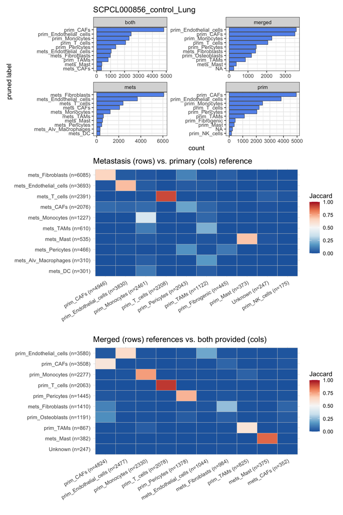

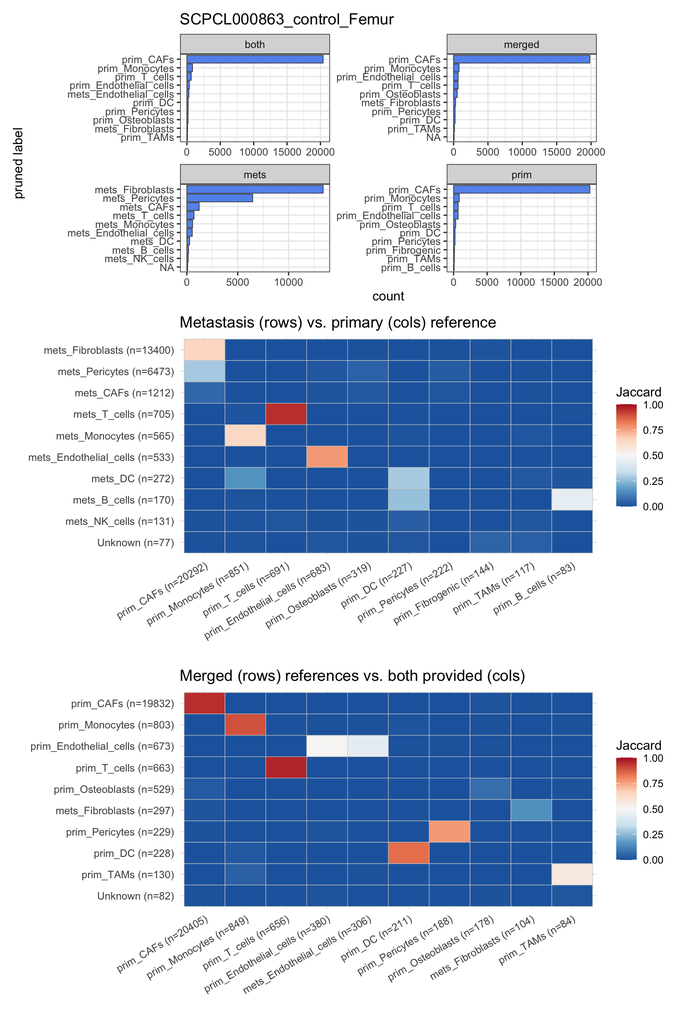

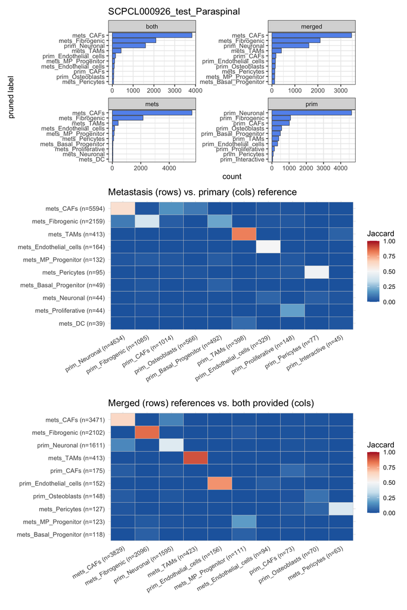

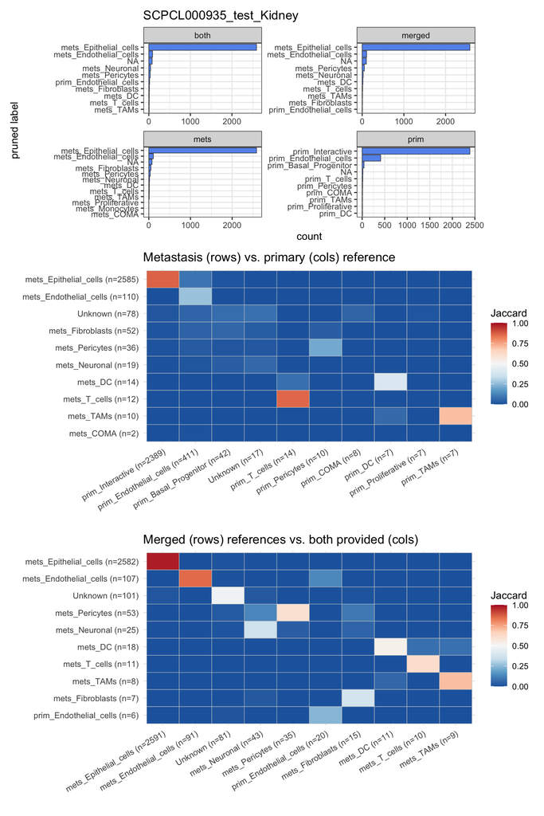

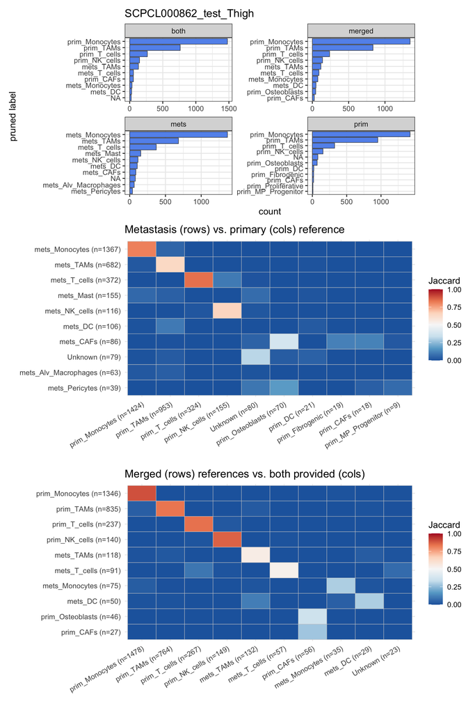

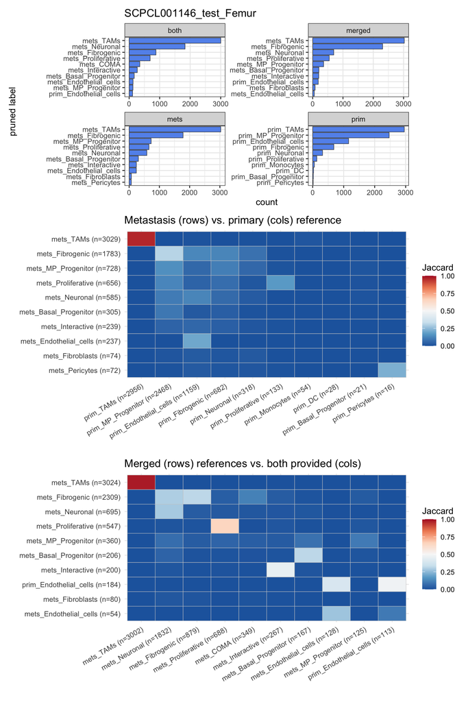

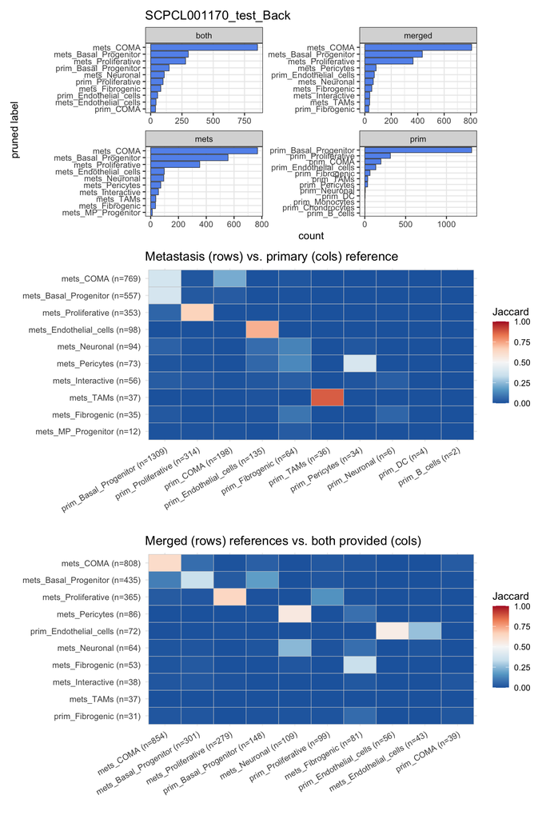

```r
result_list |>
  purrr::imap(plot_results)
```

## Conclusions

### Control lung mets sample

- This did not return a straightforward answer that suggests to use the mets reference - it seems that many primary reference cell types are coming back from each of the “merged” and “both” strategies and these results do not fully agree with the results from mets alone.
- Importantly, `Fibroblasts` is *only* a cell type in the mets reference, not the prim, but we only see this dominating in the results when mets is used. When either of the both/merged is used, cell types from the prim reference seem to become much more prominent, in particular CAFs and Endothelial cells, and fibroblasts tends to lose out to those options.

For this one, it’s helpful to also look at the mets vs. both heatmap:

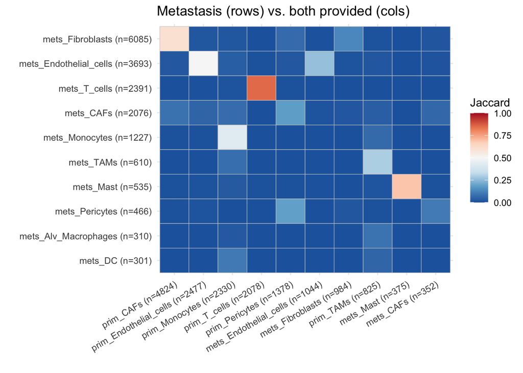

```r
make_jaccard_df(result_list$SCPCL000856_control_Lung$mets, result_list$SCPCL000856_control_Lung$both) |>
  plot_jaccard_heatmap("Metastasis (rows) vs. both provided (cols)")
```

Indeed, a lot of primary cell types are coming back that map to mets cell types, but are similarly labeled (although there’s a lot of back and forth with CAFs/pericytes). This is maybe indeed a vote for just the mets reference.

### Paraspinal metastasis

- Reasonably consistent results between the mets reference and both/merged, which themselves are fairly consistent as well
- Interestingly, we don’t really see mets neuronal, only prim neuronal, and I might expect to see this cell type for a paraspinal sample! A combined reference might be helpful here

### Kidney metastasis

- No surprise, this is a good case for mets because primary doesn’t have epithelial cells in it
- We see more NAs here too, which isn’t surprising because kidney is a rather different tissue from what the references capture

### Thigh metastasis

- Highly similar cell types are coming back regardless of the reference, and very similar results between merged/both
- Osteoblasts (albeit very small number) seem to only get returned for prim and merged, but not both

### Femur metastasis

- Fairly similar distributions across both/merged/mets, but less 1:1 between mets and prim cell types
- This one shows a lot of interplay across fibrogenic/neuronal/mp_progenitor - two of which are tumor but neuronal is classified in the mesenchymal higher-level annotation

For this one, it’s helpful to also look at the mets vs. both heatmap:

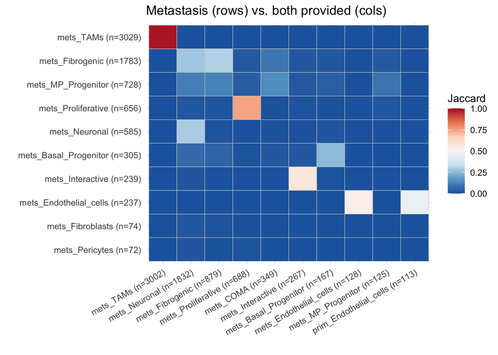

```r
make_jaccard_df(result_list$SCPCL001146_test_Femur$mets, result_list$SCPCL001146_test_Femur$both) |>
  plot_jaccard_heatmap("Metastasis (rows) vs. both provided (cols)")
```

Again cell types tend to match up well between references, which is nice to see but there is still some fibrogenic/neuronal/mp_progenitor blending.

## Deciding which references to use

We clearly see from this exploration that, between mets and prim references, some shared cell type labels have shared expression patterns but other shared labels do not. This echoes observations from heatmaps in `02-compare-references.Rmd`, and suggests that a joint reference approach may be preferable in general especially if it is not very *contradictory* with using a single reference for a well-matched case. The question remains, which approach should we use to combine references? In cases where we might want to use both references, which approach should we use? This exploration was not definitive either way, since the results from these two combined approaches are similar but certainly not identical. But, we can think about the methods we’ll be using:

- `SingleR` generally suggests to use the “both” strategy (don’t merge them but send them in together), and it uses its own algorithm for deciding between them
- But, over in `scANVI`, we don’t have an apples-to-apples version of that; we would instead have to concatenate references and that project samples on top of that joint projection

Of course the underlying algorithms are fairly distinct here, but to retain a shared approach it may be best to indeed concatenate (the “merged” strategy here) references for `SingleR`.